# fireexposuR

This document aims to guide users through the functionality of this package for different use cases. After reading this page, the user should be able to determine the input data they will require to apply the functions in this package.

## Spatial data in R

The spatial operations in *fireexposuR* are done using the `{terra}` package (Hijmans 2024). If you have not worked with spatial data in the R environment before it is a good idea to take some time to read the documentation there to understand the spatial datatypes required in this package. There are many useful tutorials at https://rspatial.org. At a minimum, I recommend reading the documentation for the following functions:

- Reading spatial data: [`terra::vect()`] and [`terra::rast()`]
- Writing spatial data: [`terra::writeVector()`] and [`terra::writeRaster()`]

## 1. Determine scale

First, consider what scale(s) of wildfire transmission you are interested in assessing. Methods in wildfire exposure can be applied for various scales of wildfire transmission. Input data requirements will vary depending on the scale of assessment.

### Landscape

Landscape scale wildfire exposure assessments are concerned with large, and often fast, wildfire ignition potential in natural wildland fuels. These assessments can be conducted for large extents (e.g., country, province (Beverly et al. 2021), state (Schmidt et al. 2024)) or focused near a value of interest (e.g., a community buffer (Beverly and Forbes 2023; Kim et al. 2023)). Only fuels that have the potential to produce long-range embers are considered for landscape scale exposure assessments.

### Local

Local scale wildfire exposure assessments can also incorporate shorter transmission distances. Local scale assessments can be used to understand values are exposed to surrounding wildland fuels. This includes long-range ember exposure, but can also incorporate shorter wildfire transmission distances like short-range embers or radiant heat exposure.

### Understanding transmission distances

The defaults for the wildfire transmission distances are based on Beverly et al. (2010) and Beverly et al. (2021).

#### Long-range embers

The transmission distance for long-range embers is defined as 500 meters. In reality, under extreme conditions some wildland fuels have the potential to transmit long-range embers at distances much greater than 500 meters; However, this value has been validated for the exposure metric in Alberta (Beverly et al. 2021), Alaska (Schmidt et al. 2024), Portugal (manuscript in preparation), and across the entire Canadian landbase (manuscript in preparation).

#### Short-range embers and radiant heat

The transmission distance for short-range embers is defined as 100 meters and the transmission distance for radiant heat transmission is defined as 30 meters. Some wildland fuels have the potential transmit fire over shorter distances, but are less likely to contribute to landscape scale processes.

## 2. Determine scope

Second, consider which analyses you are interested in using the package for. Determining the scope will inform the required spatial resolution and extent of the input data, which is further documented in `vignette("prep-input-data")`.

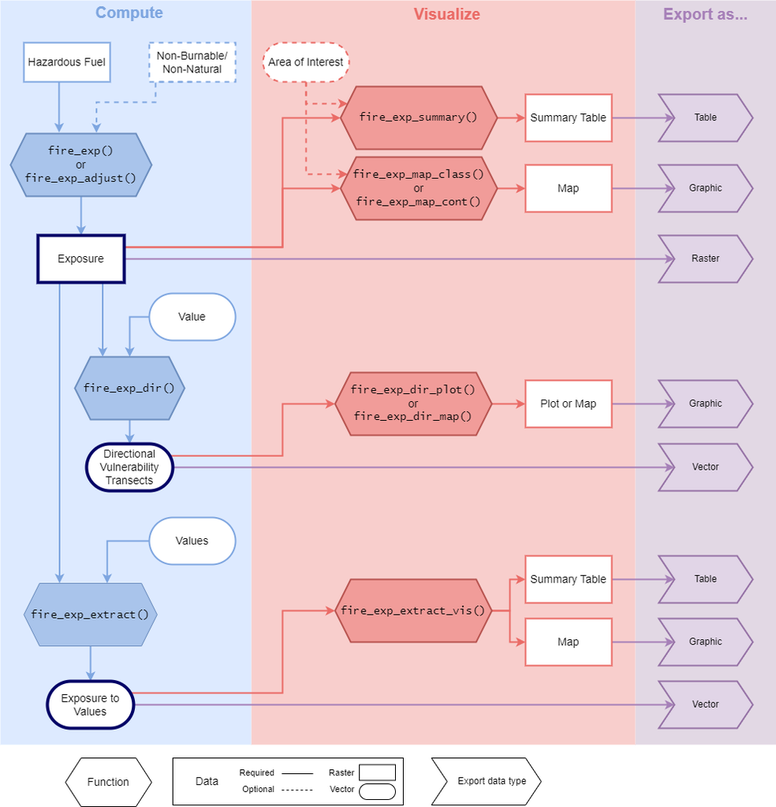

Here are some common use case examples with suggested package functions and required input data.

### Example: Compute exposure

The simplest use case of this package is computing the exposure metric. All of the other functions in this package require this as the first step. This can be computed for all scales of wildfire transmission.

Analysis functions:

- `fire_exp()` : Compute exposure with default transmission distances
- `fire_exp_adjust()` : Compute exposure with custom transmission distances

Visualization functions:

- `fire_exp_map_cont()` : Visualize exposure mapped with a continuous scale
- `fire_exp_map_class()` : Visualize exposure mapped with a classified scale
- `fire_exp_summary()` : Visualize exposure classes in a summary table

Required input data:

- a Raster representing hazardous fuels in the area of interest
  - if you are interested in more than one wildfire transmission distance, you will need one hazardous fuel raster for each transmission distance of interest

Optional input data:

- a raster representing the non-natural (e.g., the built environment) and non-burnable (e.g., open water, exposed rocks) landscape

Additional data for visualization:

- a polygon vector feature to mask the visualizations to an area of interest

*Further suggested reading:* Beverly et al. 2021, Beverly et al. 2010, FireSmart Canada 2018, Schmidt et al. 2024

#### Example workflow

This example code demonstrates how to use the package to compute wildfire exposure at two different scales of wildfire transmission and then export the results as a .tif file. For advice on preparing the input data see `vignette("prep-input-data")`.

```r
# Load the fireexposuR library
library(fireexposuR)

# Load the terra library for reading/writing spatial data
library(terra)

# read raster of wildland fuels hazardous for long-range ember transmission
hazard_long <- rast("long_range_hazard.tif")

# read raster of wildland fuels hazardous for short-range ember transmission
hazard_short <- rast("short_range_hazard.tif")

# compute long-range ember exposure using the long-range hazard layer
exposure_long <- fire_exp(hazard_long, tdist = "l")

# compute short-range ember exposure using the short-range hazard layer
exposure_short <- fire_exp(hazard_short, tdist = "s")

# Export the results as a .tif file using terra
writeRaster(exposure_long, "exposure_long.tif")
writeRaster(exposure_short, "exposure_short.tif")
```

### Example: Assess directional exposure

Assessing the directional exposure vulnerability toward a value of interest is a landscape scale process. This assessment is used to identify potential pathways a wildfire could traverse toward a value in a systematic radial pattern.

Analysis functions:

- `fire_exp_dir()` : Assess directional exposure

Visualization functions:

- `fire_exp_dir_plot()` : Visualize the directional transects in a plot
- `fire_exp_dir_map()` : Visualize the directional transects in a map
- `fire_exp_dir_multi()` : Visualize directional exposure trends for multiple values

Required input data:

- a Raster representing long-range exposure (e.g., from `fire_exp()`)
- point or simplified polygon vector feature of a value (or values) of interest

*Further suggested reading:* Beverly and Forbes 2023

#### Example workflow

This example code demonstrates how to use the package to assess directional vulnerability for a single point value and multiple point values. The example code also shows how to export the results as shapefiles.

```r
# Load the fireexposuR library
library(fireexposuR)

# Load the terra library for reading/writing spatial data
library(terra)


# PLEASE NOTE: The following code is to demonstrate an example workflow. The
# referenced input data does not exist.

# read raster of wildland fuels hazardous for long-range ember transmission
hazard_long <- rast("long_range_hazard.tif")

# compute long-range ember exposure using the long-range hazard layer
exposure_long <- fire_exp(hazard_long, tdist = "l")

# read point feature vector of a single value location
point_value <- vect("point_value.shp")

# read point feature vector of value locations
multiple_values <- vect("multiple_values.shp")

# assess directional exposure for a single point
transects_point <- fire_exp_dir(exposure_long, point_value)

# export the transects for the point feature as a shapefile with terra
writeVector(transects_point, "transects_point.shp")

# loop through multiple values and export the results as shapefiles
for (i in seq_len(nrow(multiple_values))) {
  dir_exp_point <- fire_exp_dir(exposure_long, multiple_values[i])
  # set a file name based on the feature row number
  file_name <- paste("transects_point_", i, ".shp", sep = "")
  writeVector(dir_exp_point, file_name)
}
```